# 과제

Park, Soomin

2019 7 2

### 1.

##### 부모의 키가 클수록 자식의 키도 상대적으로 크다고 하는데, 아버지의 키와 아들의 키를 조사하였더니 아래와 같이 나왔다고 한다. 이 자료를 바탕으로 해서 회귀식을 구하고 아버지의 키가 165cm일 때 아들의 키는 얼마인지 예측하시오

```r
father <- c(150,160,170,180,190)
son <- c(176, 179, 182,181,185)
data <- data.frame(father=father, son=son)

(fit <- lm(son~father, data=data))
```

```
##
## Call:
## lm(formula = son ~ father, data = data)
##
## Coefficients:
## (Intercept)       father
##       146.6          0.2
```

```r
summary(fit)
```

```
##
## Call:
## lm(formula = son ~ father, data = data)
##
## Residuals:
##    1    2    3    4    5
## -0.6  0.4  1.4 -1.6  0.4
##
## Coefficients:
##              Estimate Std. Error t value Pr(>|t|)
## (Intercept) 146.60000    7.10211  20.642 0.000249 ***
## father        0.20000    0.04163   4.804 0.017171 *
## ---
## Signif. codes:  0 '***' 0.001 '**' 0.01 '*' 0.05 '.' 0.1 ' ' 1
##
## Residual standard error: 1.317 on 3 degrees of freedom
## Multiple R-squared:  0.885,  Adjusted R-squared:  0.8466
## F-statistic: 23.08 on 1 and 3 DF,  p-value: 0.01717
```

```r
father_height <- 165
(son_height <- 146.6 + 0.2 *father_height )
```

```
## [1] 179.6
```

### 2.

##### 소득이 높을수록 신용카드 사용량이 많아진다고 하는데, 월 소득 대비 신용카드 사용량을 조사하였더니 아래와 같이 나왔다고 한다. 이 자료를 바탕으로 해서 회귀식을 구하고, 월 소득이 250만원일 때 신용카드 사용량을 예측하시오.

##### (단위: 만원) 월 소득(x): 100 200 300 400 500 카드 사용량(y): 30 70 85 140 197

```r
income <- c(100,  200,  300,  400,  500)
card <- c(30, 70,  85,  140,  197)
data <- data.frame(income=income, card=card)

(fit <- lm (card ~ income, data = data))
```

```
##
## Call:
## lm(formula = card ~ income, data = data)
##
## Coefficients:
## (Intercept)       income
##     -16.800        0.404
```

```r
summary(fit)
```

```
##
## Call:
## lm(formula = card ~ income, data = data)
##
## Residuals:
##     1     2     3     4     5
##   6.4   6.0 -19.4  -4.8  11.8
##
## Coefficients:
##             Estimate Std. Error t value Pr(>|t|)
## (Intercept) -16.8000    15.0240  -1.118  0.34495
## income        0.4040     0.0453   8.919  0.00297 **
## ---
## Signif. codes:  0 '***' 0.001 '**' 0.01 '*' 0.05 '.' 0.1 ' ' 1
##
## Residual standard error: 14.32 on 3 degrees of freedom
## Multiple R-squared:  0.9637, Adjusted R-squared:  0.9515
## F-statistic: 79.54 on 1 and 3 DF,  p-value: 0.002974
```

```r
x <- 250
(y <- -16.8 + 0.404*x)
```

```
## [1] 84.2
```

### 3.

##### mtcars 데이터셋에서 배기량(disp)에 따른 마력(hp)의 회귀식을 구하시오

```r
mtcars
```

```
##                      mpg cyl  disp  hp drat    wt  qsec vs am gear carb
## Mazda RX4           21.0   6 160.0 110 3.90 2.620 16.46  0  1    4    4
## Mazda RX4 Wag       21.0   6 160.0 110 3.90 2.875 17.02  0  1    4    4
## Datsun 710          22.8   4 108.0  93 3.85 2.320 18.61  1  1    4    1
## Hornet 4 Drive      21.4   6 258.0 110 3.08 3.215 19.44  1  0    3    1
## Hornet Sportabout   18.7   8 360.0 175 3.15 3.440 17.02  0  0    3    2
## Valiant             18.1   6 225.0 105 2.76 3.460 20.22  1  0    3    1
## Duster 360          14.3   8 360.0 245 3.21 3.570 15.84  0  0    3    4
## Merc 240D           24.4   4 146.7  62 3.69 3.190 20.00  1  0    4    2
## Merc 230            22.8   4 140.8  95 3.92 3.150 22.90  1  0    4    2
## Merc 280            19.2   6 167.6 123 3.92 3.440 18.30  1  0    4    4
## Merc 280C           17.8   6 167.6 123 3.92 3.440 18.90  1  0    4    4
## Merc 450SE          16.4   8 275.8 180 3.07 4.070 17.40  0  0    3    3
## Merc 450SL          17.3   8 275.8 180 3.07 3.730 17.60  0  0    3    3
## Merc 450SLC         15.2   8 275.8 180 3.07 3.780 18.00  0  0    3    3
## Cadillac Fleetwood  10.4   8 472.0 205 2.93 5.250 17.98  0  0    3    4
## Lincoln Continental 10.4   8 460.0 215 3.00 5.424 17.82  0  0    3    4
## Chrysler Imperial   14.7   8 440.0 230 3.23 5.345 17.42  0  0    3    4
## Fiat 128            32.4   4  78.7  66 4.08 2.200 19.47  1  1    4    1
## Honda Civic         30.4   4  75.7  52 4.93 1.615 18.52  1  1    4    2
## Toyota Corolla      33.9   4  71.1  65 4.22 1.835 19.90  1  1    4    1
## Toyota Corona       21.5   4 120.1  97 3.70 2.465 20.01  1  0    3    1
## Dodge Challenger    15.5   8 318.0 150 2.76 3.520 16.87  0  0    3    2
## AMC Javelin         15.2   8 304.0 150 3.15 3.435 17.30  0  0    3    2
## Camaro Z28          13.3   8 350.0 245 3.73 3.840 15.41  0  0    3    4
## Pontiac Firebird    19.2   8 400.0 175 3.08 3.845 17.05  0  0    3    2
## Fiat X1-9           27.3   4  79.0  66 4.08 1.935 18.90  1  1    4    1
## Porsche 914-2       26.0   4 120.3  91 4.43 2.140 16.70  0  1    5    2
## Lotus Europa        30.4   4  95.1 113 3.77 1.513 16.90  1  1    5    2
## Ford Pantera L      15.8   8 351.0 264 4.22 3.170 14.50  0  1    5    4
## Ferrari Dino        19.7   6 145.0 175 3.62 2.770 15.50  0  1    5    6
## Maserati Bora       15.0   8 301.0 335 3.54 3.570 14.60  0  1    5    8
## Volvo 142E          21.4   4 121.0 109 4.11 2.780 18.60  1  1    4    2
```

```r
(fit <- lm(hp~disp, data=mtcars))
```

```
##
## Call:
## lm(formula = hp ~ disp, data = mtcars)
##
## Coefficients:
## (Intercept)         disp
##     45.7345       0.4376
```

```r
summary(fit)
```

```
##
## Call:
## lm(formula = hp ~ disp, data = mtcars)
##
## Residuals:
##     Min      1Q  Median      3Q     Max
## -48.623 -28.378  -6.558  13.588 157.562
##
## Coefficients:
##             Estimate Std. Error t value Pr(>|t|)
## (Intercept)  45.7345    16.1289   2.836  0.00811 **
## disp          0.4375     0.0618   7.080 7.14e-08 ***
## ---
## Signif. codes:  0 '***' 0.001 '**' 0.01 '*' 0.05 '.' 0.1 ' ' 1
##
## Residual standard error: 42.65 on 30 degrees of freedom
## Multiple R-squared:  0.6256, Adjusted R-squared:  0.6131
## F-statistic: 50.13 on 1 and 30 DF,  p-value: 7.143e-08
```

```r
x <- 0
y <- 45.735 + 0.4376 * x
```

### 4.

##### MASS 패키지를 설치하고, 이 패키지 안에 있는 Boston 데이터셋을 이용하여 Boston 인근의 집값을 결정하는 다중회귀 모델을 만드시오.

###### * 참조 Modelling Home Prices (R) by Campos, David and Eulogio, Raul 모범답안 by 황성윤

```r
library(MASS)
library(ggplot2)
str(Boston)
```

```
## 'data.frame':    506 obs. of  14 variables:
##  $ crim   : num  0.00632 0.02731 0.02729 0.03237 0.06905 ...
##  $ zn     : num  18 0 0 0 0 0 12.5 12.5 12.5 12.5 ...
##  $ indus  : num  2.31 7.07 7.07 2.18 2.18 2.18 7.87 7.87 7.87 7.87 ...
##  $ chas   : int  0 0 0 0 0 0 0 0 0 0 ...
##  $ nox    : num  0.538 0.469 0.469 0.458 0.458 0.458 0.524 0.524 0.524 0.524 ...
##  $ rm     : num  6.58 6.42 7.18 7 7.15 ...
##  $ age    : num  65.2 78.9 61.1 45.8 54.2 58.7 66.6 96.1 100 85.9 ...
##  $ dis    : num  4.09 4.97 4.97 6.06 6.06 ...
##  $ rad    : int  1 2 2 3 3 3 5 5 5 5 ...
##  $ tax    : num  296 242 242 222 222 222 311 311 311 311 ...
##  $ ptratio: num  15.3 17.8 17.8 18.7 18.7 18.7 15.2 15.2 15.2 15.2 ...
##  $ black  : num  397 397 393 395 397 ...
##  $ lstat  : num  4.98 9.14 4.03 2.94 5.33 ...
##  $ medv   : num  24 21.6 34.7 33.4 36.2 28.7 22.9 27.1 16.5 18.9 ...
```

```r
bos <- Boston
head(bos)
```

```
##      crim zn indus chas   nox    rm  age    dis rad tax ptratio  black
## 1 0.00632 18  2.31    0 0.538 6.575 65.2 4.0900   1 296    15.3 396.90
## 2 0.02731  0  7.07    0 0.469 6.421 78.9 4.9671   2 242    17.8 396.90
## 3 0.02729  0  7.07    0 0.469 7.185 61.1 4.9671   2 242    17.8 392.83
## 4 0.03237  0  2.18    0 0.458 6.998 45.8 6.0622   3 222    18.7 394.63
## 5 0.06905  0  2.18    0 0.458 7.147 54.2 6.0622   3 222    18.7 396.90
## 6 0.02985  0  2.18    0 0.458 6.430 58.7 6.0622   3 222    18.7 394.12
##   lstat medv
## 1  4.98 24.0
## 2  9.14 21.6
## 3  4.03 34.7
## 4  2.94 33.4
## 5  5.33 36.2
## 6  5.21 28.7
```

###### chas 데이터는 찰스 강을 기준으로 한 dummy variable 이므로 factor 화 한다.

```r
bos$chas <- as.factor(bos$chas)
```

######rad 데이터는 방사성 고속도로로의 접근성을 index 화 한 것. 이는 접근성에 따라 ordered 되어있으므로 level 을 더한다.

```r
bos$rad <- as.factor(bos$rad)
levels (bos$rad)
```

```
## [1] "1"  "2"  "3"  "4"  "5"  "6"  "7"  "8"  "24"
```

###### 대략적인 데이터의 분포와 추이를 보기 위해 histogram 과 boxplot 을 종속변수인 medv 에 대해 그린다.

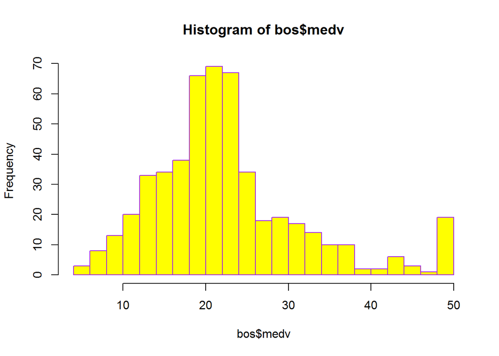

```r
hist (bos$medv, breaks= 20 ,
      col = 'yellow', border = 'purple')
```

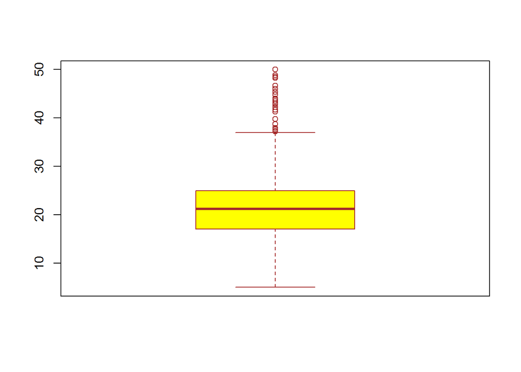

```r
boxplot (bos$medv, col = 'yellow', border = 'brown')
```

###### 위의 그래프들에 따르면 medv 는 오른쪽으로 skewed 되어있는 형태의 분포이며 다수의 outlier 가 존재하는 것으로 보인다.

###### 종속변수를 포함하여 데이터 셋의 여러 변수를 포함한 산점도를 그린다.

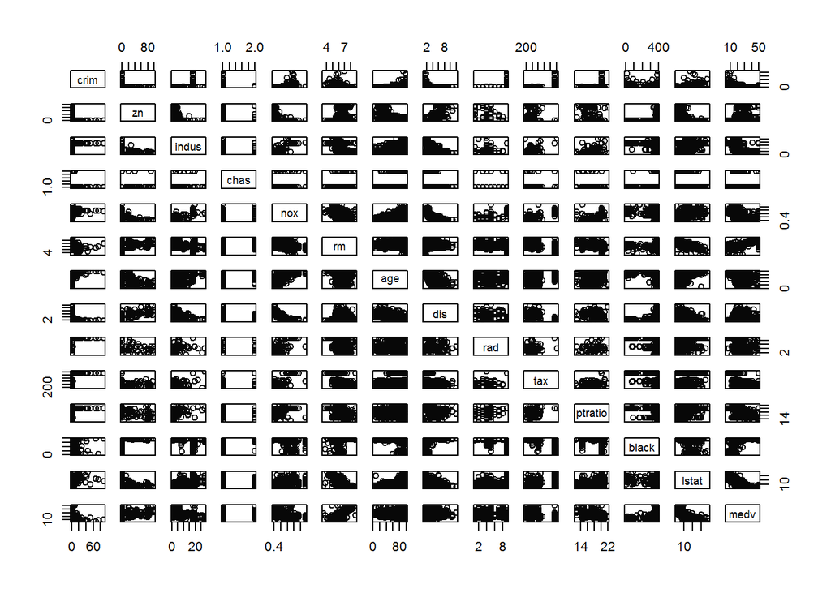

```r
plot (bos, col = 'grey3')
```

###### 패턴 상 한정된 값의 팩터인 chas 와 rad 는 산점도를 통해 correlation 을 보기 어려우므로 제외.

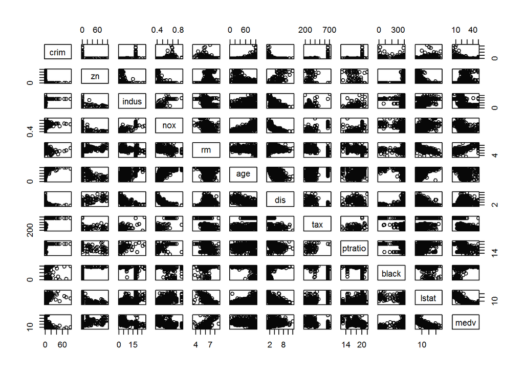

```r
plot (bos[,-c(4, 9)], col = 'grey3')
```

#### I . linear regression model

```r
(fit <- lm(medv~. , data=bos))
```

```
##
## Call:
## lm(formula = medv ~ ., data = bos)
##
## Coefficients:
## (Intercept)         crim           zn        indus        chas1
##   35.259615    -0.108821     0.054896     0.023760     2.524163
##         nox           rm          age          dis         rad2
##  -17.573132     3.665491     0.000461    -1.554546     1.488905
##        rad3         rad4         rad5         rad6         rad7
##    4.681253     2.576234     2.918493     1.185839     4.878992
##        rad8        rad24          tax      ptratio        black
##    4.839836     7.461674    -0.008748    -0.972419     0.009394
##       lstat
##   -0.529226
```

```r
summary (fit)
```

```
##
## Call:
## lm(formula = medv ~ ., data = bos)
##
## Residuals:
##      Min       1Q   Median       3Q      Max
## -15.1020  -2.7355  -0.4565   1.6821  25.9450
##
## Coefficients:
##               Estimate Std. Error t value Pr(>|t|)
## (Intercept)  35.259615   5.433641   6.489 2.14e-10 ***
## crim         -0.108821   0.032685  -3.329 0.000937 ***
## zn            0.054896   0.014149   3.880 0.000119 ***
## indus         0.023760   0.063648   0.373 0.709081
## chas1         2.524163   0.863181   2.924 0.003614 **
## nox         -17.573132   3.896362  -4.510 8.13e-06 ***
## rm            3.665491   0.421196   8.703  < 2e-16 ***
## age           0.000461   0.013227   0.035 0.972210
## dis          -1.554546   0.201909  -7.699 7.75e-14 ***
## rad2          1.488905   1.477509   1.008 0.314095
## rad3          4.681254   1.335295   3.506 0.000498 ***
## rad4          2.576234   1.187369   2.170 0.030514 *
## rad5          2.918493   1.207610   2.417 0.016028 *
## rad6          1.185839   1.464013   0.810 0.418342
## rad7          4.878992   1.571198   3.105 0.002012 **
## rad8          4.839836   1.491657   3.245 0.001257 **
## rad24         7.461674   1.788679   4.172 3.58e-05 ***
## tax          -0.008748   0.003895  -2.246 0.025144 *
## ptratio      -0.972419   0.144478  -6.731 4.78e-11 ***
## black         0.009394   0.002661   3.531 0.000454 ***
## lstat        -0.529226   0.050640 -10.451  < 2e-16 ***
## ---
## Signif. codes:  0 '***' 0.001 '**' 0.01 '*' 0.05 '.' 0.1 ' ' 1
##
## Residual standard error: 4.694 on 485 degrees of freedom
## Multiple R-squared:  0.7499, Adjusted R-squared:  0.7396
## F-statistic:  72.7 on 20 and 485 DF,  p-value: < 2.2e-16
```

```r
anova(fit)
```

```
## Analysis of Variance Table
##
## Response: medv
##            Df  Sum Sq Mean Sq  F value    Pr(>F)
## crim        1  6440.8  6440.8 292.3589 < 2.2e-16 ***
## zn          1  3554.3  3554.3 161.3378 < 2.2e-16 ***
## indus       1  2551.2  2551.2 115.8053 < 2.2e-16 ***
## chas        1  1529.8  1529.8  69.4426 8.149e-16 ***
## nox         1    76.2    76.2   3.4610  0.063437 .
## rm          1 10938.1 10938.1 496.5010 < 2.2e-16 ***
## age         1    90.3    90.3   4.0974  0.043496 *
## dis         1  1779.5  1779.5  80.7748 < 2.2e-16 ***
## rad         8   948.7   118.6   5.3831 1.672e-06 ***
## tax         1   154.3   154.3   7.0021  0.008406 **
## ptratio     1   953.6   953.6  43.2844 1.229e-10 ***
## black       1   608.5   608.5  27.6205 2.216e-07 ***
## lstat       1  2406.1  2406.1 109.2194 < 2.2e-16 ***
## Residuals 485 10684.7    22.0
## ---
## Signif. codes:  0 '***' 0.001 '**' 0.01 '*' 0.05 '.' 0.1 ' ' 1
```

##### stepwise regression

###### 1. backward

```r
step(fit, direction = 'backward')
```

```
## Start:  AIC=1585.32
## medv ~ crim + zn + indus + chas + nox + rm + age + dis + rad +
##     tax + ptratio + black + lstat
##
##           Df Sum of Sq   RSS    AIC
## - age      1      0.03 10685 1583.3
## - indus    1      3.07 10688 1583.5
## <none>                 10685 1585.3
## - tax      1    111.15 10796 1588.5
## - chas     1    188.39 10873 1592.2
## - crim     1    244.20 10929 1594.8
## - black    1    274.62 10959 1596.2
## - zn       1    331.63 11016 1598.8
## - nox      1    448.13 11133 1604.1
## - rad      8    873.19 11558 1609.1
## - ptratio  1    997.99 11683 1628.5
## - dis      1   1305.93 11991 1641.7
## - rm       1   1668.47 12353 1656.7
## - lstat    1   2406.15 13091 1686.1
##
## Step:  AIC=1583.32
## medv ~ crim + zn + indus + chas + nox + rm + dis + rad + tax +
##     ptratio + black + lstat
##
##           Df Sum of Sq   RSS    AIC
## - indus    1      3.07 10688 1581.5
## <none>                 10685 1583.3
## - tax      1    111.27 10796 1586.6
## - chas     1    189.01 10874 1590.2
## - crim     1    244.18 10929 1592.8
## - black    1    276.15 10961 1594.2
## - zn       1    334.32 11019 1596.9
## - nox      1    477.15 11162 1603.4
## - rad      8    875.17 11560 1607.2
## - ptratio  1   1007.34 11692 1626.9
## - dis      1   1427.54 12112 1644.8
## - rm       1   1729.50 12414 1657.2
## - lstat    1   2723.34 13408 1696.2
##
## Step:  AIC=1581.46
## medv ~ crim + zn + chas + nox + rm + dis + rad + tax + ptratio +
##     black + lstat
##
##           Df Sum of Sq   RSS    AIC
## <none>                 10688 1581.5
## - tax      1    117.31 10805 1585.0
## - chas     1    196.24 10884 1588.7
## - crim     1    247.07 10935 1591.0
## - black    1    274.60 10962 1592.3
## - zn       1    332.21 11020 1595.0
## - nox      1    496.04 11184 1602.4
## - rad      8    894.44 11582 1606.1
## - ptratio  1   1004.27 11692 1624.9
## - dis      1   1516.24 12204 1646.6
## - rm       1   1733.41 12421 1655.5
## - lstat    1   2722.70 13410 1694.3
```

```
##
## Call:
## lm(formula = medv ~ crim + zn + chas + nox + rm + dis + rad +
##     tax + ptratio + black + lstat, data = bos)
##
## Coefficients:
## (Intercept)         crim           zn        chas1          nox
##   35.175681    -0.109352     0.054066     2.559259   -17.136641
##          rm          dis         rad2         rad3         rad4
##    3.651923    -1.571146     1.567130     4.660505     2.605151
##        rad5         rad6         rad7         rad8        rad24
##    2.899961     1.124387     4.873446     4.794374     7.336238
##         tax      ptratio        black        lstat
##   -0.008124    -0.969091     0.009369    -0.527494
```

###### age 와 indus 가 무의미한 변수로 파악되어 제거 되었다.

###### 2. forward

```r
step(lm(medv~1, data=bos), direction='forward',
     scope = ~crim+zn+indus+chas+nox+rm+age+dis+rad+tax+ptratio+black+lstat)
```

```
## Start:  AIC=2246.51
## medv ~ 1
##
##           Df Sum of Sq   RSS    AIC
## + lstat    1   23243.9 19472 1851.0
## + rm       1   20654.4 22062 1914.2
## + ptratio  1   11014.3 31702 2097.6
## + indus    1    9995.2 32721 2113.6
## + tax      1    9377.3 33339 2123.1
## + rad      8    9767.3 32949 2131.2
## + nox      1    7800.1 34916 2146.5
## + crim     1    6440.8 36276 2165.8
## + age      1    6069.8 36647 2171.0
## + zn       1    5549.7 37167 2178.1
## + black    1    4749.9 37966 2188.9
## + dis      1    2668.2 40048 2215.9
## + chas     1    1312.1 41404 2232.7
## <none>                 42716 2246.5
##
## Step:  AIC=1851.01
## medv ~ lstat
##
##           Df Sum of Sq   RSS    AIC
## + rm       1    4033.1 15439 1735.6
## + ptratio  1    2670.1 16802 1778.4
## + rad      8    1344.8 18128 1830.8
## + chas     1     786.3 18686 1832.2
## + dis      1     772.4 18700 1832.5
## + age      1     304.3 19168 1845.0
## + tax      1     274.4 19198 1845.8
## + black    1     198.3 19274 1847.8
## + zn       1     160.3 19312 1848.8
## + crim     1     146.9 19325 1849.2
## + indus    1      98.7 19374 1850.4
## <none>                 19472 1851.0
## + nox      1       4.8 19468 1852.9
##
## Step:  AIC=1735.58
## medv ~ lstat + rm
##
```

[output cut: 109 more lines]

```
##
##         Df Sum of Sq   RSS    AIC
## + tax    1   117.306 10688 1581.5
## <none>               10805 1585.0
## + indus  1     9.104 10796 1586.6
## + age    1     0.207 10805 1587.0
##
## Step:  AIC=1581.46
## medv ~ lstat + rm + ptratio + dis + nox + chas + black + rad +
##     zn + crim + tax
##
##         Df Sum of Sq   RSS    AIC
## <none>               10688 1581.5
## + indus  1    3.0690 10685 1583.3
## + age    1    0.0256 10688 1583.5
```

```
##
## Call:
## lm(formula = medv ~ lstat + rm + ptratio + dis + nox + chas +
##     black + rad + zn + crim + tax, data = bos)
##
## Coefficients:
## (Intercept)        lstat           rm      ptratio          dis
##   35.175681    -0.527494     3.651923    -0.969091    -1.571146
##         nox        chas1        black         rad2         rad3
##  -17.136641     2.559259     0.009369     1.567130     4.660505
##        rad4         rad5         rad6         rad7         rad8
##    2.605151     2.899961     1.124387     4.873446     4.794374
##       rad24           zn         crim          tax
##    7.336238     0.054066    -0.109352    -0.008124
```

###### 마찬가지로 age 와 indus 를 제외한 모든 변수가 유의미하다고 파악되었다.

###### 3. both direction

```r
step(fit, direction = 'both')
```

```
## Start:  AIC=1585.32
## medv ~ crim + zn + indus + chas + nox + rm + age + dis + rad +
##     tax + ptratio + black + lstat
##
##           Df Sum of Sq   RSS    AIC
## - age      1      0.03 10685 1583.3
## - indus    1      3.07 10688 1583.5
## <none>                 10685 1585.3
## - tax      1    111.15 10796 1588.5
## - chas     1    188.39 10873 1592.2
## - crim     1    244.20 10929 1594.8
## - black    1    274.62 10959 1596.2
## - zn       1    331.63 11016 1598.8
## - nox      1    448.13 11133 1604.1
## - rad      8    873.19 11558 1609.1
## - ptratio  1    997.99 11683 1628.5
## - dis      1   1305.93 11991 1641.7
## - rm       1   1668.47 12353 1656.7
## - lstat    1   2406.15 13091 1686.1
##
## Step:  AIC=1583.32
## medv ~ crim + zn + indus + chas + nox + rm + dis + rad + tax +
##     ptratio + black + lstat
##
##           Df Sum of Sq   RSS    AIC
## - indus    1      3.07 10688 1581.5
## <none>                 10685 1583.3
## + age      1      0.03 10685 1585.3
## - tax      1    111.27 10796 1586.6
## - chas     1    189.01 10874 1590.2
## - crim     1    244.18 10929 1592.8
## - black    1    276.15 10961 1594.2
## - zn       1    334.32 11019 1596.9
## - nox      1    477.15 11162 1603.4
## - rad      8    875.17 11560 1607.2
## - ptratio  1   1007.34 11692 1626.9
## - dis      1   1427.54 12112 1644.8
## - rm       1   1729.50 12414 1657.2
## - lstat    1   2723.34 13408 1696.2
##
## Step:  AIC=1581.46
## medv ~ crim + zn + chas + nox + rm + dis + rad + tax + ptratio +
##     black + lstat
##
##           Df Sum of Sq   RSS    AIC
## <none>                 10688 1581.5
## + indus    1      3.07 10685 1583.3
## + age      1      0.03 10688 1583.5
## - tax      1    117.31 10805 1585.0
## - chas     1    196.24 10884 1588.7
## - crim     1    247.07 10935 1591.0
## - black    1    274.60 10962 1592.3
## - zn       1    332.21 11020 1595.0
## - nox      1    496.04 11184 1602.4
## - rad      8    894.44 11582 1606.1
## - ptratio  1   1004.27 11692 1624.9
## - dis      1   1516.24 12204 1646.6
## - rm       1   1733.41 12421 1655.5
## - lstat    1   2722.70 13410 1694.3
```

```
##
## Call:
## lm(formula = medv ~ crim + zn + chas + nox + rm + dis + rad +
##     tax + ptratio + black + lstat, data = bos)
##
## Coefficients:
## (Intercept)         crim           zn        chas1          nox
##   35.175681    -0.109352     0.054066     2.559259   -17.136641
##          rm          dis         rad2         rad3         rad4
##    3.651923    -1.571146     1.567130     4.660505     2.605151
##        rad5         rad6         rad7         rad8        rad24
##    2.899961     1.124387     4.873446     4.794374     7.336238
##         tax      ptratio        black        lstat
##   -0.008124    -0.969091     0.009369    -0.527494
```

###### 쌍방으로 검사한 결과도 동일하므로 앞으로의 과정에ㅅ는 age 와 indus 를 제외한 분석을 한다.

###### 4. leap

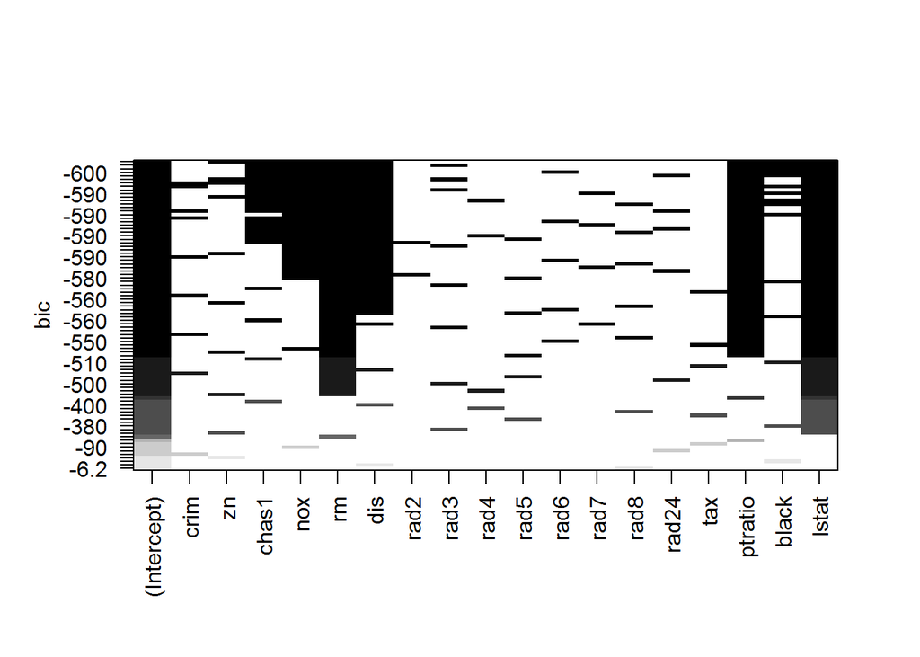

```r
library(leaps)
subset1 <- regsubsets(medv~., data = bos[, -c(3,7)],
                     method = 'seqrep', nbest=11)
plot(subset1)
```

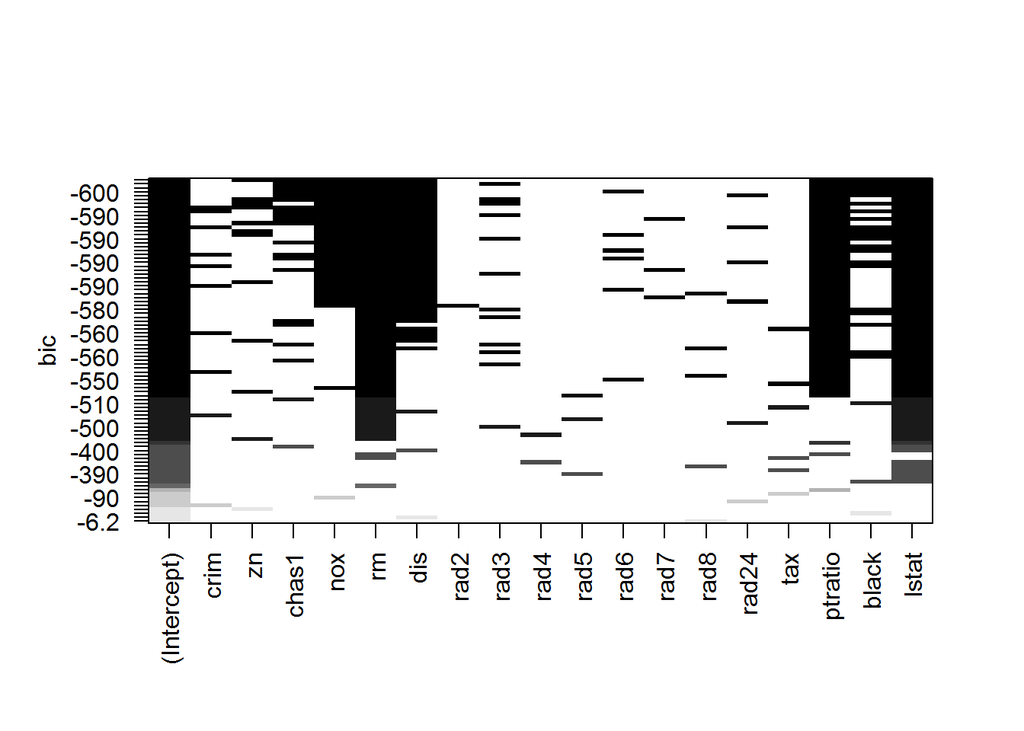

```r
subset2 <- regsubsets(medv~., data = bos[, -c(3,7)],
                     method = 'exhaustive', nbest=11)
plot(subset2)
```

###### subset2 # 확인 결과 rad 가 factor label 별로 하나씩 항목을 차지하고 있음이 보인다. 이를 막기 위해 rad 항목을 제외한다.

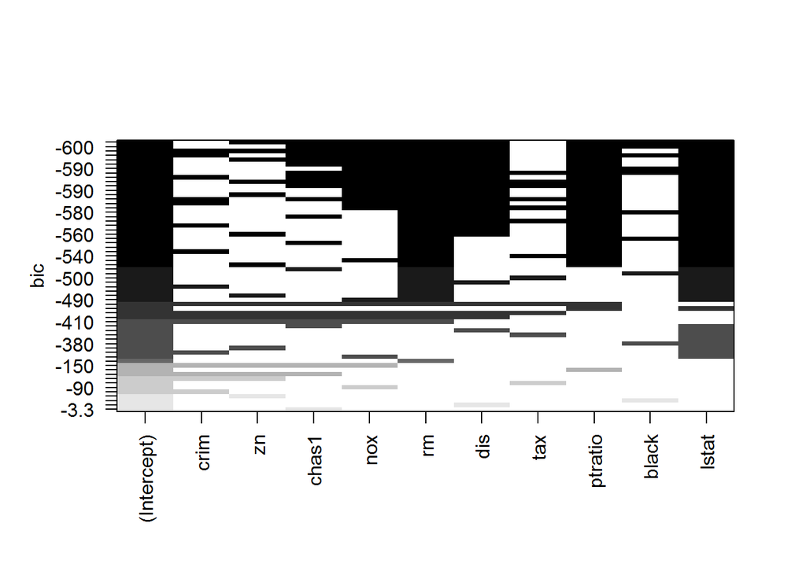

```r
subset1 <- regsubsets(medv~., data = bos[, -c(3,7,9)],
                      method = 'seqrep', nbest=11)
plot(subset1)
```

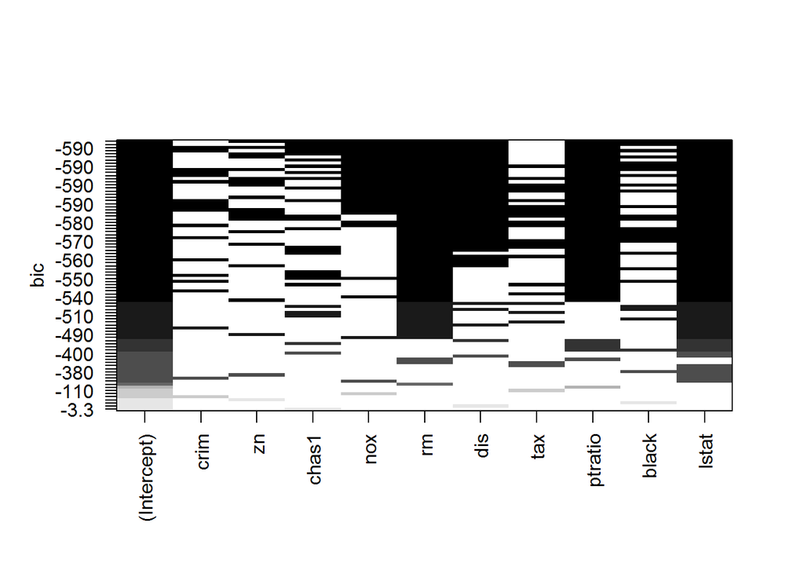

```r
subset2 <- regsubsets(medv~., data = bos[, -c(3,7,9)],
                      method = 'exhaustive', nbest=11)
plot(subset2)
```

###### BIC 그래프 모형에 따르면 crim 과 tax 가 무의미하게 판정된다. 따라서 앞으로의 검정에서 crim, tax, age, indus, rad 를 제외시킨다.

#### II. 기타 model

###### 다중선형회귀 모델 구축시 잔차에 대한 다음과 같은 가정을 한다. 정규성 (normality) 등분산성 (homoscedaticity) 선형성 (linearity) 독립성 (idependence)

###### 위의 step 과 leap regression 을 통해 판정한 변수들을 제외한 모델을 구축

```r
fit2 <- lm(medv~zn+chas+nox+rm+dis+ptratio+black+lstat,data=bos)
```

###### 이의 정규성, 등분산성, 선형성 및 독립성을 확인한다.

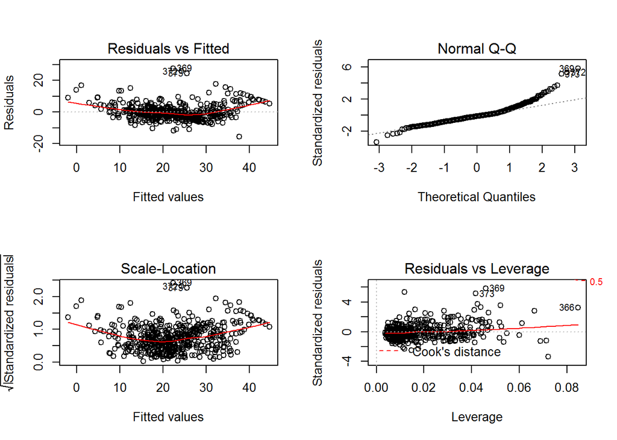

```r
par(mfrow=c(2,2)) ; plot (fit2)
```

```r
par(mfrow=c(1,1))
```

###### 1. 정규성

```r
shapiro.test(fit2$residuals)  # p-value = 0.000 < 0.05 로 정규성 거짓
```

```
##
##  Shapiro-Wilk normality test
##
## data:  fit2$residuals
## W = 0.90172, p-value < 2.2e-16
```

###### 2. 등분산성 및 선형성 gvlma 패키지의 gvlma 함수가 등분산성과 선형성을 검정한다. global test : 선형성, heteroscedasticity : 등분산성

```r
library(gvlma)
(gvmodel <- gvlma(fit2))
```

```
##
## Call:
## lm(formula = medv ~ zn + chas + nox + rm + dis + ptratio + black +
##     lstat, data = bos)
##
## Coefficients:
## (Intercept)           zn        chas1          nox           rm
##   30.316950     0.037808     3.111062   -16.687428     4.116082
##         dis      ptratio        black        lstat
##   -1.382714    -0.881851     0.009404    -0.543125
##
##
## ASSESSMENT OF THE LINEAR MODEL ASSUMPTIONS
## USING THE GLOBAL TEST ON 4 DEGREES-OF-FREEDOM:
## Level of Significance =  0.05
##
## Call:
##  gvlma(x = fit2)
##
##                     Value   p-value                   Decision
## Global Stat        982.78 0.000e+00 Assumptions NOT satisfied!
## Skewness           191.69 0.000e+00 Assumptions NOT satisfied!
## Kurtosis           638.54 0.000e+00 Assumptions NOT satisfied!
## Link Function      131.69 0.000e+00 Assumptions NOT satisfied!
## Heteroscedasticity  20.86 4.931e-06 Assumptions NOT satisfied!
```

###### p-value 가 global, heteroscedatiscity 둘 다 < 0.05 이므로 선형성, 등분산성 모두 거짓.

###### 3. 독립성

###### Durbin-Watson 검정법으로 독립성을 검정한다.이 때는 DW statistic == 2 일 때 독립, ==0 일때 양의 자기상관, ==4 일때 음의 자기상관으로 판정한다.

```r
library(car)
durbinWatsonTest(fit2)
```

```
##  lag Autocorrelation D-W Statistic p-value
##    1       0.4588323      1.067548       0
##  Alternative hypothesis: rho != 0
```

###### p-value = 0 <0.05 이므로 독립성이 거짓.

##### 결과적으로 fit2 는 다중선형회귀분석에 대한 기본가정을 만족하지 못한다.그러나 현 과제 특성상 이 모델로 우선 진행한다.

###### 다중공선성 multicollinearity 를 검정하기 위해 vif 테스트를 시행한다. vif 값이 5보다 높을 경우 문제가 있는 것으로 판단한다.

```r
vif(fit2)
```

```
##       zn     chas      nox       rm      dis  ptratio    black    lstat
## 2.067289 1.049615 3.008635 1.771292 3.353885 1.348840 1.247488 2.488640
```

###### multicollinearity 문제는 없을 것으로 보인다.

###### outlier 을 찾아내기 위해 outlierTesT() 를 시행한다.

```r
outlierTest(fit2, cutoff= Inf, n.max=8)
```

```
##      rstudent unadjusted p-value Bonferroni p
## 369  6.045232         2.9359e-09   1.4856e-06
## 372  5.507836         5.8418e-08   2.9559e-05
## 373  5.293814         1.8026e-07   9.1210e-05
## 370  3.798788         1.6345e-04   8.2707e-02
## 413  3.614324         3.3188e-04   1.6793e-01
## 365 -3.397779         7.3400e-04   3.7140e-01
## 371  3.328561         9.3787e-04   4.7456e-01
## 366  3.284137         1.0952e-03   5.5419e-01
```

```r
bos2 <- bos[-c(369,372,373,370,413,365,371,366), -c(1,3,7, 9, 10)]
fit3 <- lm(medv~., data = bos2)
summary(fit3)
```

```
##
## Call:
## lm(formula = medv ~ ., data = bos2)
##
## Residuals:
##     Min      1Q  Median      3Q     Max
## -12.641  -2.473  -0.297   1.909  18.376
##
## Coefficients:
##               Estimate Std. Error t value Pr(>|t|)
## (Intercept)  19.170869   4.193613   4.571 6.14e-06 ***
## zn            0.019742   0.011059   1.785   0.0749 .
## chas1         1.797013   0.758891   2.368   0.0183 *
## nox         -16.663271   2.708060  -6.153 1.58e-09 ***
## rm            5.588609   0.362366  15.423  < 2e-16 ***
## dis          -0.972008   0.157352  -6.177 1.37e-09 ***
## ptratio      -1.014856   0.097426 -10.417  < 2e-16 ***
## black         0.011322   0.002207   5.131 4.16e-07 ***
## lstat        -0.378121   0.041991  -9.005  < 2e-16 ***
## ---
## Signif. codes:  0 '***' 0.001 '**' 0.01 '*' 0.05 '.' 0.1 ' ' 1
##
## Residual standard error: 4.005 on 489 degrees of freedom
## Multiple R-squared:  0.7981, Adjusted R-squared:  0.7948
## F-statistic: 241.6 on 8 and 489 DF,  p-value: < 2.2e-16
```

###### zn 은 무의미한 변수로 판정되고, chas 도 약한 연관성을 보이나 나머지 변수들은 매우 유의미하게 판정된다.

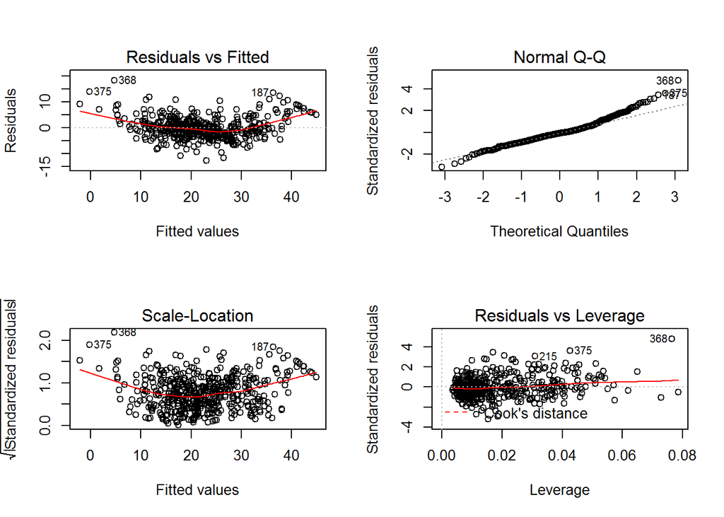

```r
par(mfrow=c(2,2))
plot(fit3)
```

###### 지난 fit, fit2 그래프보다 확연히 좋아진 linearity 가 확인된다. 그러나 여전히 non-linear 하다고 보인다.

###### 따라서 polynomial 을 더해주는 것이 어떠한지 보도록 한다.

###### 지난 분석들 및 초반의 산점도를 볼 때 lstat 과 medv 사이의 polynomial 관계식이 의심된다.

```r
(fit4 <- lm(medv~. +I(lstat^2), data = bos2))
```

```
##
## Call:
## lm(formula = medv ~ . + I(lstat^2), data = bos2)
##
## Coefficients:
## (Intercept)           zn        chas1          nox           rm
##    25.31872      0.00305      1.96927    -13.65865      4.96393
##         dis      ptratio        black        lstat   I(lstat^2)
##    -0.90761     -0.88487      0.01038     -1.26236      0.02474
```

```r
summary(fit4)
```

```
##
## Call:
## lm(formula = medv ~ . + I(lstat^2), data = bos2)
##
## Residuals:
##      Min       1Q   Median       3Q      Max
## -10.9039  -2.3969  -0.2048   1.8636  17.5368
##
## Coefficients:
##               Estimate Std. Error t value Pr(>|t|)
## (Intercept)  25.318716   3.974649   6.370 4.37e-10 ***
## zn            0.003050   0.010492   0.291  0.77139
## chas1         1.969268   0.707895   2.782  0.00561 **
## nox         -13.658650   2.548980  -5.358 1.30e-07 ***
## rm            4.963928   0.345552  14.365  < 2e-16 ***
## dis          -0.907614   0.146910  -6.178 1.37e-09 ***
## ptratio      -0.884872   0.092084  -9.609  < 2e-16 ***
## black         0.010376   0.002060   5.036 6.69e-07 ***
## lstat        -1.262364   0.109712 -11.506  < 2e-16 ***
## I(lstat^2)    0.024743   0.002868   8.628  < 2e-16 ***
## ---
## Signif. codes:  0 '***' 0.001 '**' 0.01 '*' 0.05 '.' 0.1 ' ' 1
##
## Residual standard error: 3.735 on 488 degrees of freedom
## Multiple R-squared:  0.8248, Adjusted R-squared:  0.8216
## F-statistic: 255.3 on 9 and 488 DF,  p-value: < 2.2e-16
```

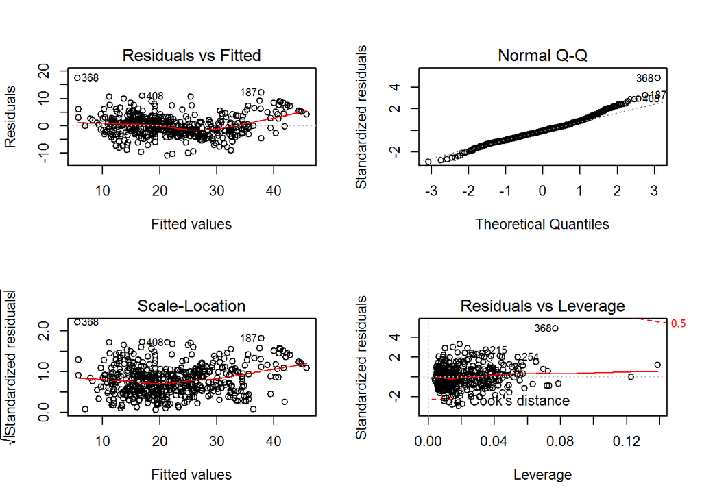

```r
par(mfrow=c(2,2))
plot(fit4)
```

###### 새로운 outlier 들이 표시되고 여전히 linearity 는 문제가 있음이 보인다.

```r
(fit5 <- lm(medv~. +I(lstat^2) +I(lstat^3), data = bos2))
```

```
##
## Call:
## lm(formula = medv ~ . + I(lstat^2) + I(lstat^3), data = bos2)
##
## Coefficients:
## (Intercept)           zn        chas1          nox           rm
##   2.801e+01    7.923e-04    1.916e+00   -1.385e+01    4.789e+00
##         dis      ptratio        black        lstat   I(lstat^2)
##  -9.025e-01   -8.899e-01    1.048e-02   -1.603e+00    4.693e-02
##  I(lstat^3)
##  -4.153e-04
```

```r
summary(fit5)
```

```
##
## Call:
## lm(formula = medv ~ . + I(lstat^2) + I(lstat^3), data = bos2)
##
## Residuals:
##      Min       1Q   Median       3Q      Max
## -10.7742  -2.3065  -0.2312   1.9521  17.3143
##
## Coefficients:
##               Estimate Std. Error t value Pr(>|t|)
## (Intercept)  2.801e+01  4.455e+00   6.286 7.24e-10 ***
## zn           7.923e-04  1.062e-02   0.075  0.94056
## chas1        1.916e+00  7.085e-01   2.705  0.00707 **
## nox         -1.385e+01  2.551e+00  -5.430 8.90e-08 ***
## rm           4.789e+00  3.695e-01  12.960  < 2e-16 ***
## dis         -9.025e-01  1.468e-01  -6.146 1.65e-09 ***
## ptratio     -8.899e-01  9.209e-02  -9.663  < 2e-16 ***
## black        1.048e-02  2.060e-03   5.087 5.20e-07 ***
## lstat       -1.603e+00  2.786e-01  -5.755 1.53e-08 ***
## I(lstat^2)   4.693e-02  1.691e-02   2.776  0.00572 **
## I(lstat^3)  -4.153e-04  3.119e-04  -1.331  0.18365
## ---
## Signif. codes:  0 '***' 0.001 '**' 0.01 '*' 0.05 '.' 0.1 ' ' 1
##
## Residual standard error: 3.732 on 487 degrees of freedom
## Multiple R-squared:  0.8255, Adjusted R-squared:  0.8219
## F-statistic: 230.3 on 10 and 487 DF,  p-value: < 2.2e-16
```

###### lstat^3 은 관계성이 무의미하다고 판정된다.

##### 따라서 fit4 model 이 현재 가장 유력한 모델으로, 즉 crim, tax, age, indus, rad 를 제외하고 lstat^2 의 독립변수가 종속 변수 medv 와 유의미한 관계가 있는 것으로 판단하고boston 의 집값 medv를 예측하기 위한 다중회귀식의 판정을 멈추도록 한다.